# Data Visualization with ggplot2

Paris Zhang

4/17/2020

Taught by *Rick Scavetta*. [Course link](https://learn.datacamp.com/courses/data-visualization-with-ggplot2-1)

```r
library(dplyr)
library(ggplot2)

# Create n by m ggplot grid
library(gridExtra)

# Read and print local images using load.image() and plot(..., axes=F)
library(imager)

# Applies classic ggplot2 theme
theme_set(theme_classic())
```

# 1. Intro

The basics of `ggplot2` — the seven different grammatical elements (layers) and aesthetic mappings.

## 1.1 Intro

MASS: Mammals

```r
library(MASS)
head(mammals)
```

```
##                    body brain
## Arctic fox        3.385  44.5
## Owl monkey        0.480  15.5
## Mountain beaver   1.350   8.1
## Cow             465.000 423.0
## Grey wolf        36.330 119.5
## Goat             27.660 115.0
```

Publication-ready plot:

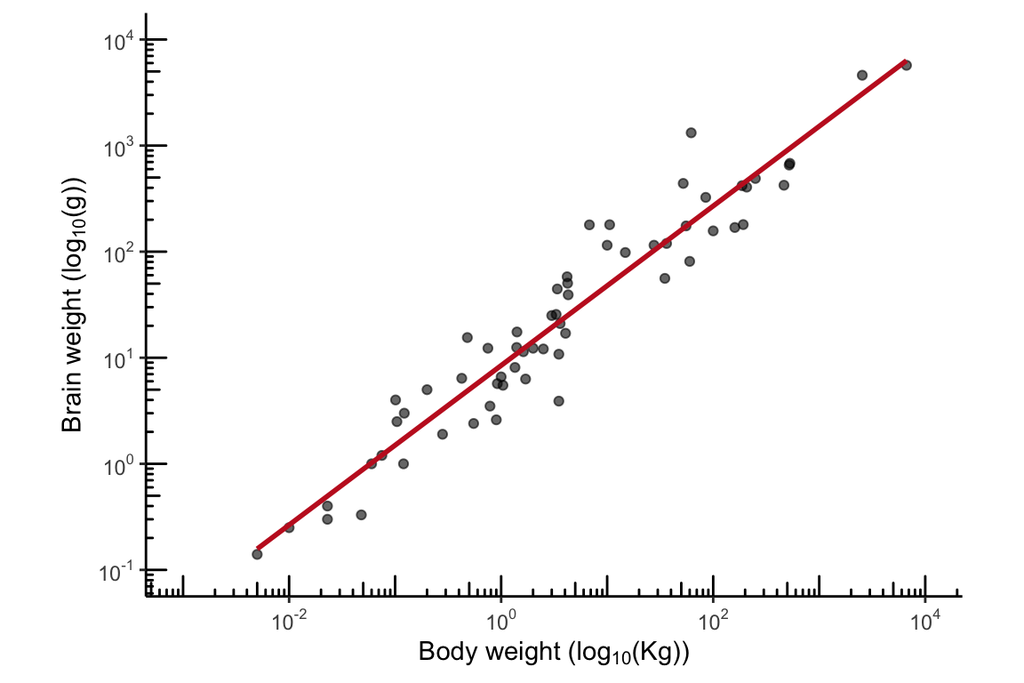

```r
library(scales) # functions trans_breaks and trans_format
ggplot(mammals, aes(x = body, y = brain)) +
 annotation_logticks() +
 geom_point(alpha = 0.6) +
 coord_fixed(xlim = c(10^-3, 10^4), ylim = c(10^-1, 10^4)) +
 scale_x_log10(expression("Body weight (log"["10"]*"(Kg))"),
               breaks = trans_breaks("log10", function(x) 10^x),
               labels = trans_format("log10", math_format(10^.x))) +
 scale_y_log10(expression("Brain weight (log"["10"]*"(g))"),
               breaks = trans_breaks("log10", function(x) 10^x),
               labels = trans_format("log10", math_format(10^.x))) +
 stat_smooth(method = "lm", col = "#C42126", se = FALSE, size = 1) +
 theme_classic()
```

## 1.2 Grammar of graphics

(Review chapter 1 slides p.40)

Essential grammatical elements:

1. Data - variables of interest
2. Aesthetics 2.1 x-axis, y-axis 2.2 colour, fill, size, labels, alpha, shape, line width, line type
3. Geometries - point, line, histogram, bar, boxplot

Optional grammatical elements:

4. Facets - columns, rows
5. Statistiscs - binning, smoothing, descriptive, inferential
6. Coordinates - cartesian, fixed, polar, limits
7. Themes - non-data ink

## 1.3 `ggplot2`

Iris dataset:

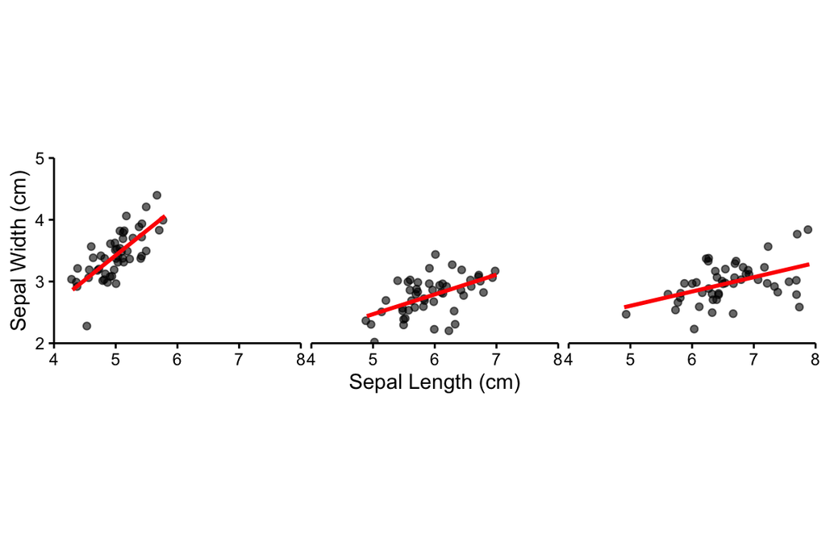

```r
levels(iris$Species) <- c("Setosa", "Versicolor", "Virginica")

ggplot(iris, aes(x = Sepal.Length, y = Sepal.Width)) +
 geom_jitter(alpha = 0.6) +
 facet_grid(. ~ Species) +
 stat_smooth(method = "lm", se = F, col = "red") +
 scale_y_continuous("Sepal Width (cm)", limits = c(2,5), expand = c(0,0)) +
 scale_x_continuous("Sepal Length (cm)", limits = c(4,8), expand = c(0,0)) +
 coord_equal() +
 theme(panel.background = element_blank(),
       plot.background = element_blank(),
       legend.background = element_blank(),
       legend.key = element_blank(),
       strip.background = element_blank(),
       axis.text = element_text(colour = "black"),
       axis.ticks = element_line(colour = "black"),
       panel.grid.major = element_blank(),
       panel.grid.minor = element_blank(),
       axis.line = element_line(colour = "black"),
       strip.text = element_blank())
```

# 2. Data

## 2.1 Objects and layers

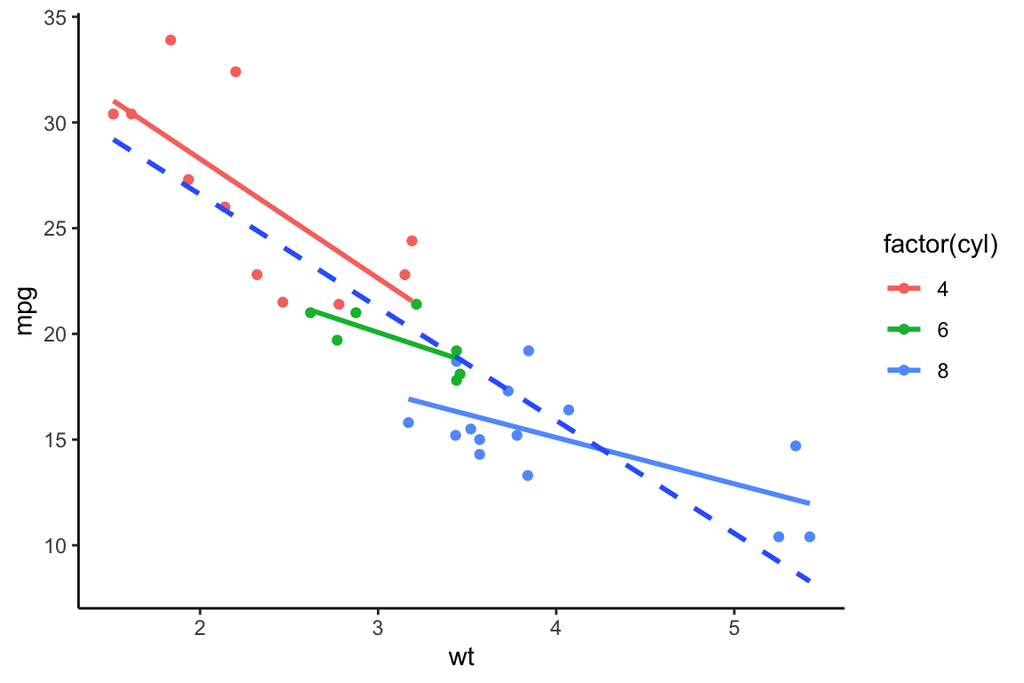

```r
# Plot 3: include a lm for the entire dataset in its whole
ggplot(mtcars, aes(x = wt, y = mpg, col = factor(cyl))) +
  geom_point() + # Copy from Plot 2
  geom_smooth(method = "lm", se = FALSE) + # Copy from Plot 2
  geom_smooth(aes(group = 1), method = "lm", se = FALSE, linetype = 2)
```

## 2.2 Proper data format

Use `iris.wide` instead of `iris`.

## 2.3 Tidy data

1. Use `gather()` and `separate()` from `tidyr` to create tidy dataset:

```r
# Load the tidyr package
library(tidyr)

iris.tidy <- iris %>%
  gather(key, Value, -Species) %>%
  separate(key, c("Part", "Measure"), "\\.")

head(iris)
```

```
##   Sepal.Length Sepal.Width Petal.Length Petal.Width Species
## 1          5.1         3.5          1.4         0.2  Setosa
## 2          4.9         3.0          1.4         0.2  Setosa
## 3          4.7         3.2          1.3         0.2  Setosa
## 4          4.6         3.1          1.5         0.2  Setosa
## 5          5.0         3.6          1.4         0.2  Setosa
## 6          5.4         3.9          1.7         0.4  Setosa
```

```r
head(iris.tidy)
```

```
##   Species  Part Measure Value
## 1  Setosa Sepal  Length   5.1
## 2  Setosa Sepal  Length   4.9
## 3  Setosa Sepal  Length   4.7
## 4  Setosa Sepal  Length   4.6
## 5  Setosa Sepal  Length   5.0
## 6  Setosa Sepal  Length   5.4
```

2. Create a wide dataset

```r
# Add column with unique ids (don't need to change)
iris$Flower <- 1:nrow(iris)

# Fill in the ___ to produce to the correct iris.wide dataset
iris.wide <- iris %>%
  gather(key, value, -Species, -Flower) %>%
  separate(key, c("Part", "Measure"), "\\.") %>%
  spread(Measure, value)

head(iris.wide)
```

```
##   Species Flower  Part Length Width
## 1  Setosa      1 Petal    1.4   0.2
## 2  Setosa      1 Sepal    5.1   3.5
## 3  Setosa      2 Petal    1.4   0.2
## 4  Setosa      2 Sepal    4.9   3.0
## 5  Setosa      3 Petal    1.3   0.2
## 6  Setosa      3 Sepal    4.7   3.2
```

# 3. Aesthetics

## 3.1 Visible aesthetics

- Data frame column mapped onto visible aesthetic: Aesthetics in `aes()`, a!ributes in `geom_()`
- **Hexadecimal colours**: Hexadecimal, literally “related to 16”, is a base-16 alphanumeric counting system. Individual values come from the ranges 0-9 and A-F. This means there are 256 possible two-digit values (i.e. 00 - FF). Hexadecimal colours use this system to specify a six-digit code for Red, Green and Blue values (“#RRGGBB”) of a colour (i.e. Pure blue: “#0000FF”, black: “#000000”, white: “#FFFFFF”). R can accept hex codes as valid colours.

## 3.2 Modifying aesthetics

`geom_bar()` positions:

- `position = "stack"` is default
- `position = "fill"`
- `position = "dodge"`

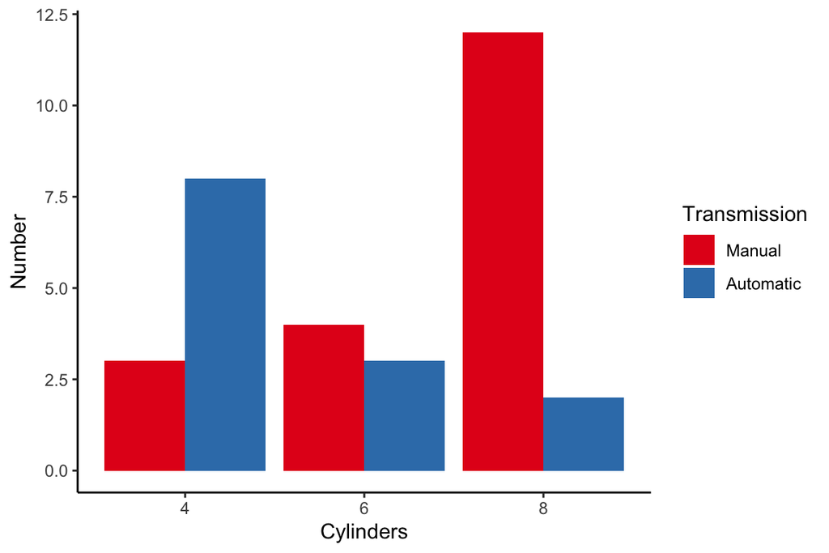

```r
val = c("#E41A1C", "#377EB8")
lab = c("Manual", "Automatic")

ggplot(mtcars, aes(x = factor(cyl), fill = factor(am))) +
  geom_bar(position = "dodge") +
  scale_x_discrete("Cylinders") +
  scale_y_continuous("Number") +
  scale_fill_manual("Transmission", values = val, labels = lab)
```

## 3.3 Aesthetics best practices

- Use `stripchart()` from `base` package to make univariate plot - it creates a fake y-axis

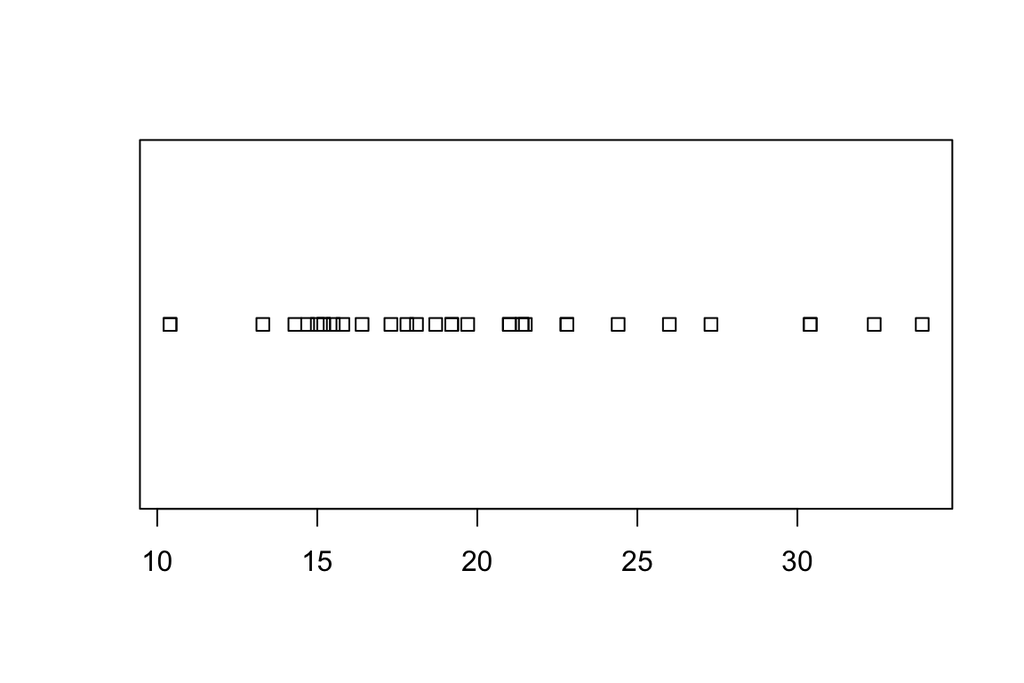

```r
stripchart(mtcars$mpg)
```

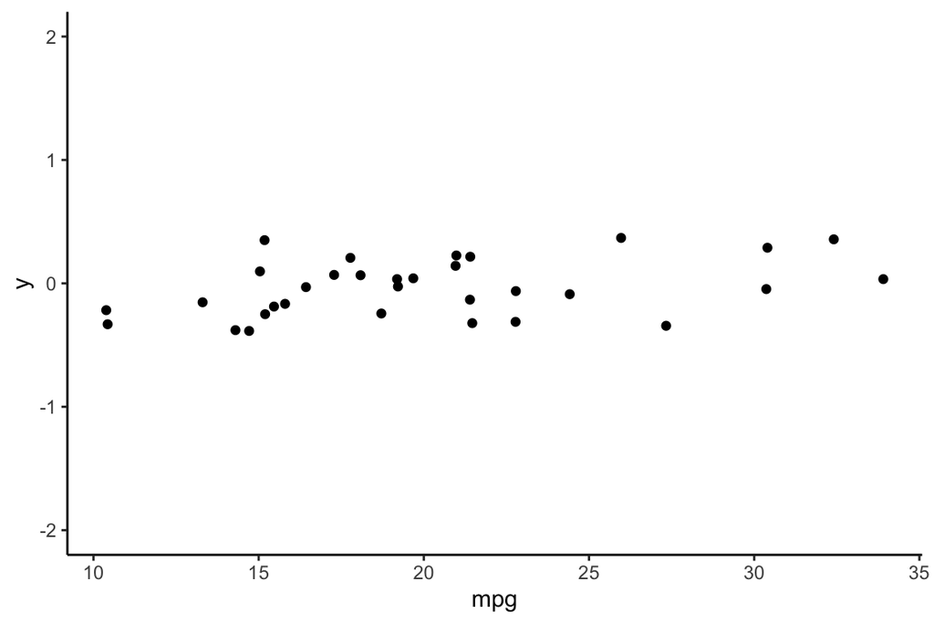

```r
ggplot(mtcars, aes(x = mpg, y = 0)) +
  geom_jitter()+
  scale_y_continuous(limits=c(-2, 2))
```

- The `diamonds` data frame is available in the `ggplot2` package.

# 4. Geometrics

1. There are 37 geometries under `ggplot2`.
2. Common plot types: 2.1 Scatter plots (points, jitter, abline) 2.1.1 `geom_jitter()` = `geom_point(position = "jitter")` 2.2 Bar plots (histogram, bar, errorbar) 2.3 Line plots (line)

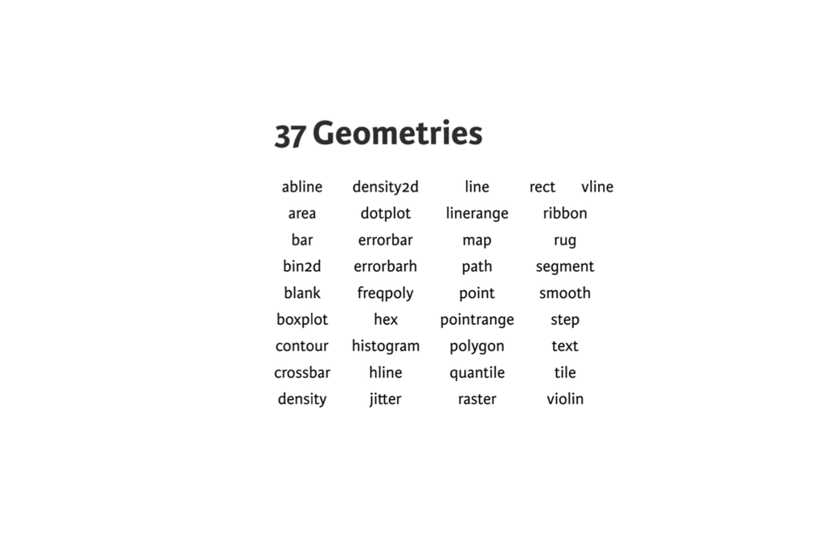

```r
p1 = load.image("slides/ch4_p1.png")
p2 = load.image("slides/ch4_p2.png")
p3 = load.image("slides/ch4_p3.png")
plot(p1, axes=FALSE)
```

## 4.1 Scatter plots

Modification with manually calculated summary statistics:

```r
head(iris)
```

```
##   Sepal.Length Sepal.Width Petal.Length Petal.Width Species Flower
## 1          5.1         3.5          1.4         0.2  Setosa      1
## 2          4.9         3.0          1.4         0.2  Setosa      2
## 3          4.7         3.2          1.3         0.2  Setosa      3
## 4          4.6         3.1          1.5         0.2  Setosa      4
## 5          5.0         3.6          1.4         0.2  Setosa      5
## 6          5.4         3.9          1.7         0.4  Setosa      6
```

```r
iris.summary <- aggregate(iris[1:4], list(iris$Species), mean)
names(iris.summary)[1] <- "Species"
iris.summary
```

```
##      Species Sepal.Length Sepal.Width Petal.Length Petal.Width
## 1     Setosa        5.006       3.428        1.462       0.246
## 2 Versicolor        5.936       2.770        4.260       1.326
## 3  Virginica        6.588       2.974        5.552       2.026
```

1. Add layers:

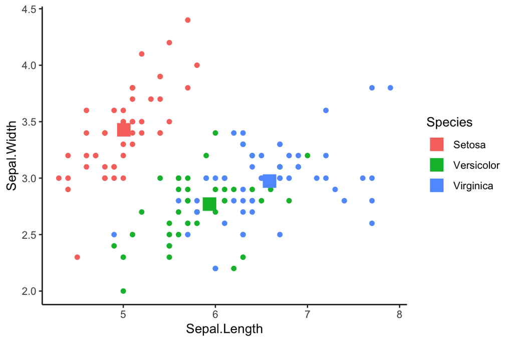

```r
ggplot(iris, aes(x = Sepal.Length, y = Sepal.Width, col = Species)) +
  geom_point() +
  geom_point(data = iris.summary, shape = 15, size = 5)
```

2. shape ~ `pch`:

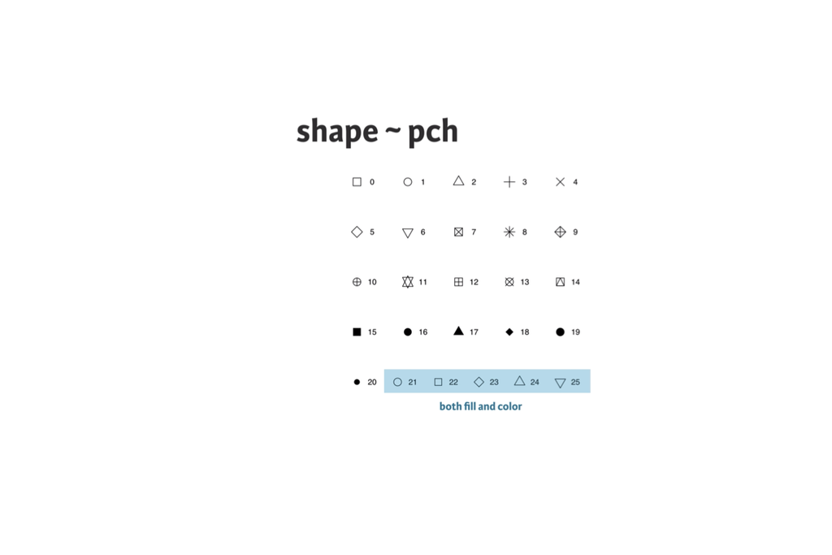

```r
plot(p2, axes=FALSE)
```

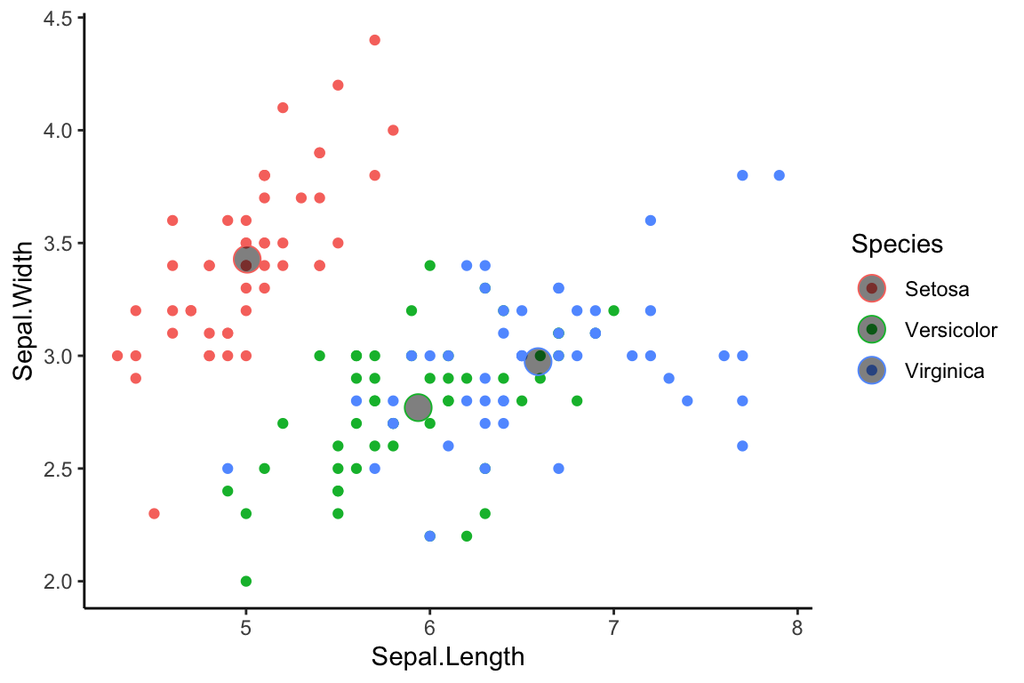

```r
ggplot(iris, aes(x = Sepal.Length, y = Sepal.Width, col = Species)) +
 geom_point() +
 geom_point(data = iris.summary, shape = 21, size = 5, fill = "#00000080")
```

3. Crosshairs with `geom_vline()` and `geom_hline()`

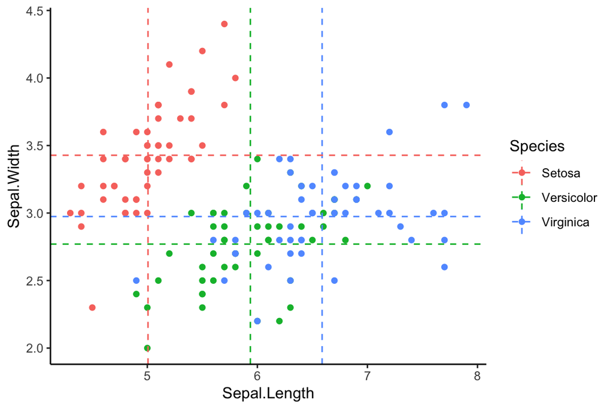

```r
ggplot(iris, aes(x = Sepal.Length, y = Sepal.Width, col = Species)) +
 geom_point() +
 geom_vline(data = iris.summary, linetype = 2,
            aes(xintercept = Sepal.Length, col = Species)) +
 geom_hline(data = iris.summary, linetype = 2,
            aes(yintercept = Sepal.Width, col = Species))
```

Different line types:

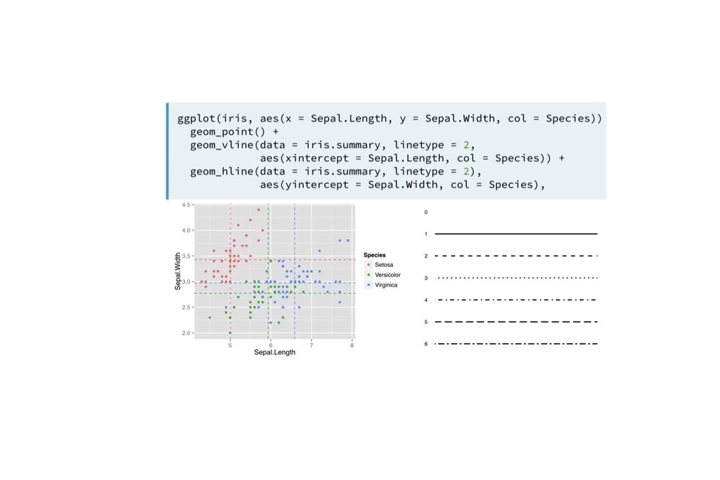

```r
plot(p3, axes = FALSE)
```

4. `geom_jitter()` with narrower width

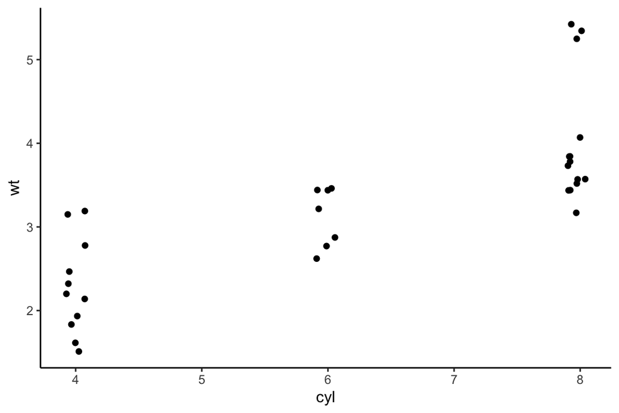

```r
ggplot(mtcars, aes(x = cyl, y = wt)) +
  geom_jitter(width=0.1)
```

## 4.2 Bar plots

1. **Histogram** - `geom_histogram()` 1.1 The default bin width is **range/30**. We could set bin width manually by `geom_histogram(binwidth = 0.1)`. 1.2 The default y-axis is count, a variable mapped to y as `..count..`. We could switch to density by setting `aes(y = ..density..)`. The double `..` means internal data frame. 1.3 There’s no space between bars. 1.4 Three `position` arguments: 1.4.1 `stack`: place the bars on top of each other. Counts are used. This is the default position. 1.4.2 `fill`: place the bars on top of each other, but this time use proportions. 1.4.3 `dodge`: place the bars next to each other. Counts are used.
2. **Bar plot** - `geom_bar()` 2.1 Two types: count and distribution. 2.2 The default `stat` is `bin`. 2.3 Set color palette with `scale_fill_brewer()`. For a full list of possible color sets, have a look at `?brewer.pal`. 2.3.1 For continuous data, the default `RColorBrewer` palette that `scale_fill_brewer()` calls is `"Blues"`.

### Ex 1. Different types of **histogram** by setting `position`:

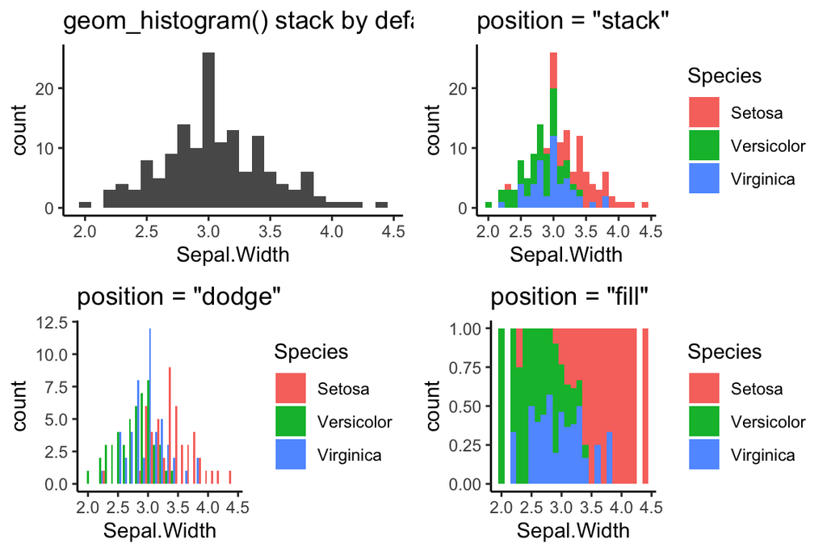

```r
hist1 = ggplot(iris, aes(x = Sepal.Width )) +
  geom_histogram(binwidth = 0.1) +
  labs(title = "geom_histogram() stack by default")
hist2 = ggplot(iris, aes(x = Sepal.Width, fill = Species)) +
  geom_histogram(binwidth = 0.1, position = "stack") +
  labs(title = "position = \"stack\"")
hist3 = ggplot(iris, aes(x = Sepal.Width, fill = Species)) +
  geom_histogram(binwidth = 0.1, position = "dodge") +
  labs(title = "position = \"dodge\"")
hist4 = ggplot(iris, aes(x = Sepal.Width, fill = Species)) +
  geom_histogram(binwidth = 0.1, position = "fill") +
  labs(title = "position = \"fill\"")

grid.arrange(hist1,hist2,hist3,hist4, nrow=2,ncol=2)
```

### Ex 2. Different types of **bar plot** using `sleep` dataset:

```r
bar1 = ggplot(sleep, aes(vore)) + geom_bar() +
  labs(title = "geom_bar() stat = \"bin\" by default")
bar2 =  ggplot(sleep, aes(vore)) + geom_bar( ) +
  labs(title = "stat = \"bin\"")

# Distribution bar plots
library(plyr)
library(reshape2) # to use melt()
iris_melted <- melt(iris, value.name = "Value", variable.name = "Measure")
iris_summ <- ddply(iris_melted[iris_melted$Measure == "Sepal.Width",],
                   "Species", summarise, avg = mean(Value), stdev = sd(Value))
bar3 =  ggplot(iris_summ, aes(x = Species, y = avg)) +
  geom_bar( stat = "identity") +
  labs(title = "stat = \"identity\"")
bar4 =  ggplot(iris_summ, aes(x = Species, y = avg)) +
  geom_bar(stat = "identity", fill = "grey50") +
  geom_errorbar(aes(ymin = avg - stdev, ymax = avg + stdev), width = 0.2) +
  labs(title = "geom_errorbar() aka dynamite plot")

grid.arrange(bar1,bar2,bar3,bar4, nrow=2,ncol=2)
```

[figure not shown]

```r
b1 = load.image("slides/ch4_bar1.png")
b3 = load.image("slides/ch4_bar2.png")
b4 = load.image("slides/ch4_bar3.png")

par(mfrow=c(2,2))
plot(b1, axes = FALSE)
plot(b1, axes = FALSE)
plot(b3, axes = FALSE)
plot(b4, axes = FALSE)
```

### Ex 3. Dodge bar plots:

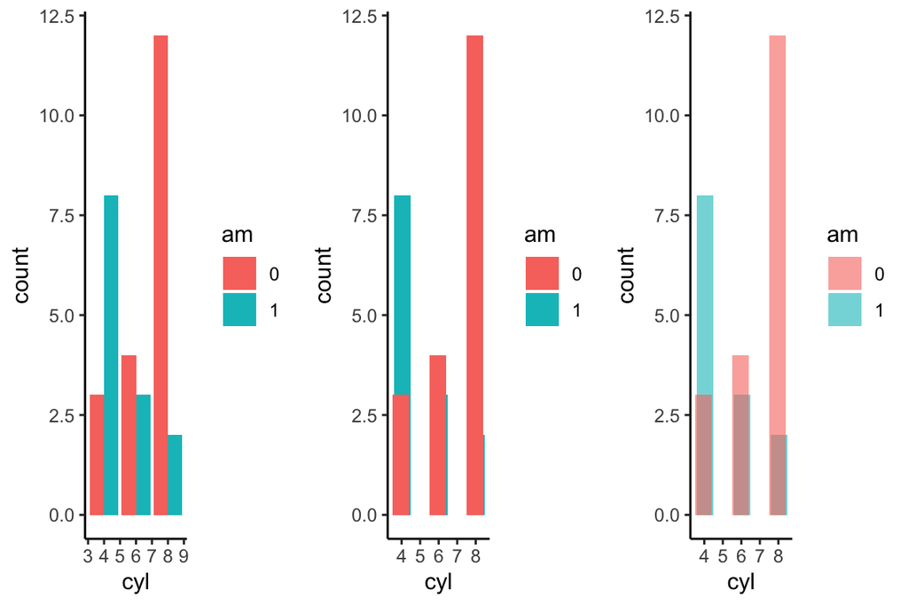

```r
mtcars$am <- as.factor(mtcars$am)

d1 = ggplot(mtcars, aes(x = cyl, fill = am)) +
  geom_bar(position = "dodge")

# 2 - Define posn_d with position_dodge()
posn_d <- position_dodge(width=0.2)
d2 = ggplot(mtcars, aes(x = cyl, fill = am)) +
  geom_bar(position = posn_d)

# 4 - Use posn_d as position and adjust alpha to 0.6
d3 = ggplot(mtcars, aes(x = cyl, fill = am)) +
  geom_bar(position = posn_d, alpha = 0.6)

grid.arrange(d1,d2,d3, nrow=1)
```

### Ex 4. Color palette

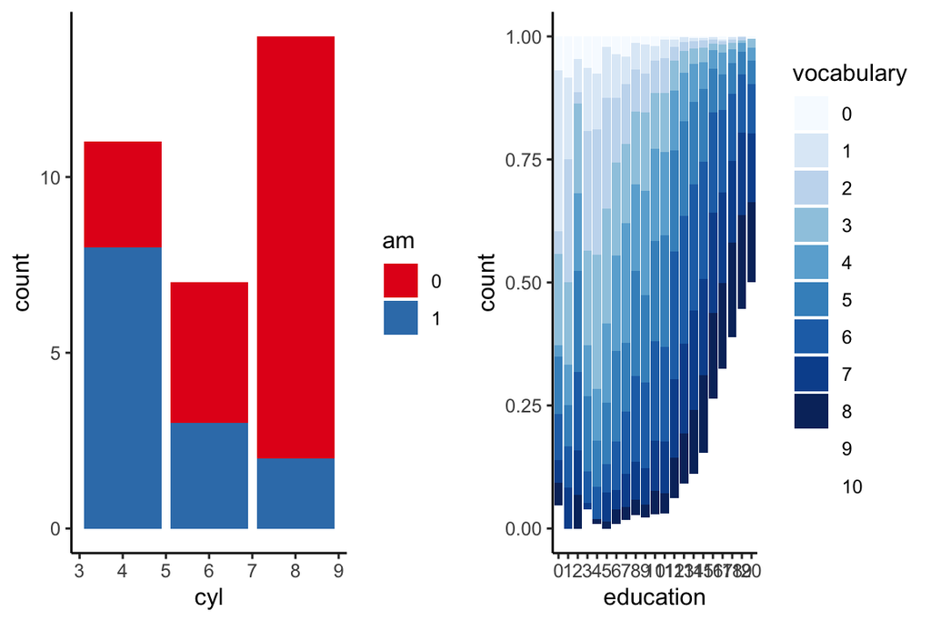

```r
pal1 = ggplot(mtcars, aes(x = cyl, fill = am)) +
  geom_bar() +
  scale_fill_brewer(palette = "Set1")

library(car) # to use Vocab
Vocab$education = as.factor(Vocab$education)
Vocab$vocabulary = as.factor(Vocab$vocabulary)
pal2 = ggplot(Vocab, aes(x=education, fill=vocabulary)) +
  geom_bar(position = "fill")+
  scale_fill_brewer()

grid.arrange(pal1,pal2, nrow=1)
```

### Ex 5. Build a color palette

`new_col()` is a function that takes one argument: the number of colours you want to extrapolate. You want to use nicer colours, so we’ve assigned the entire `"Blues"` colour palette from the `RColorBrewer` package to the character vector blues.

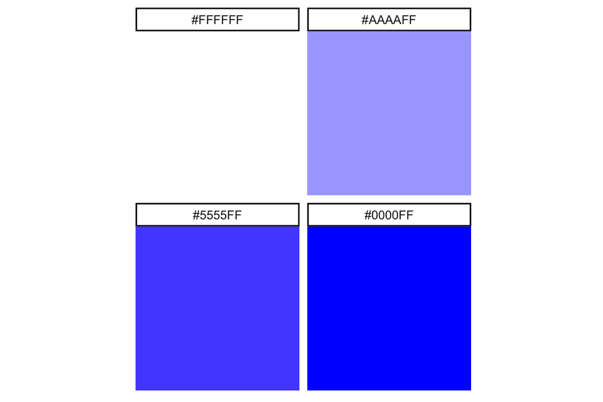

```r
new_col <- colorRampPalette(c("#FFFFFF", "#0000FF"))
# new_col(4) # the newly extrapolated colours
munsell::plot_hex(new_col(4)) # Quick and dirty plot
```

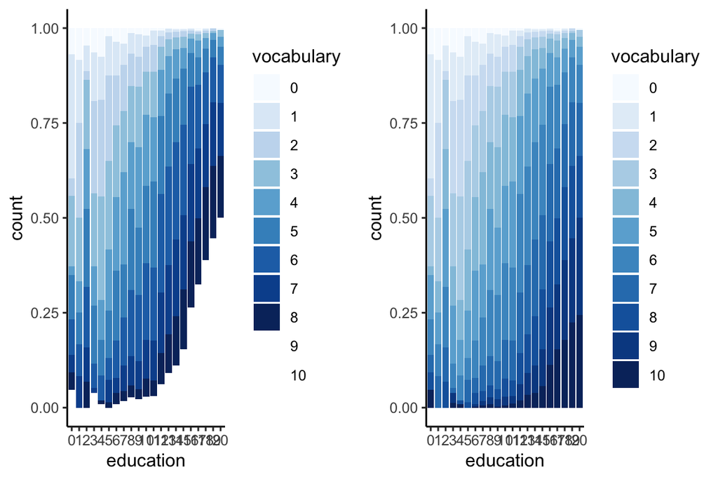

```r
library(RColorBrewer)

# Definition of a set of blue colors
blues <- brewer.pal(9, "Blues") # from the RColorBrewer package
# 1 - Make a color range using colorRampPalette() and the set of blues
blue_range <- colorRampPalette(blues)

# 2 - Use blue_range to adjust the color of the bars, use scale_fill_manual()
pal3 = ggplot(Vocab, aes(x = education, fill = vocabulary)) +
  geom_bar(position = "fill") +
  scale_fill_manual(values = blue_range(11))

grid.arrange(pal2, pal3, nrow=1)
```

### Ex 6. Overlapping histograms

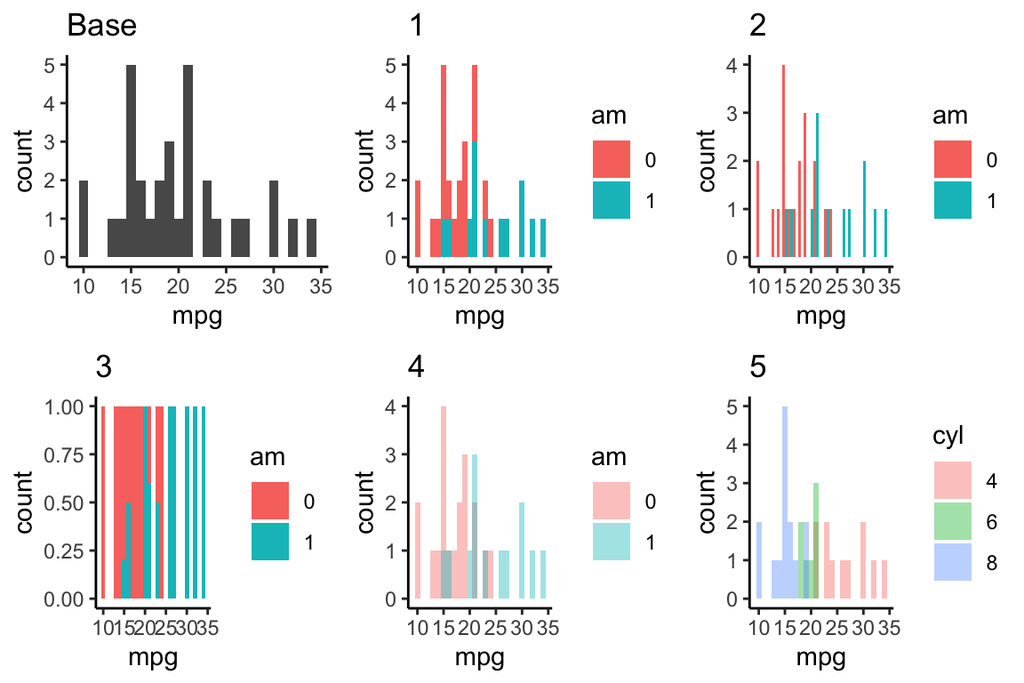

```r
mtcars$cyl = as.factor(mtcars$cyl)

# 1 - Basic histogram plot command
o1 = ggplot(mtcars, aes(mpg)) +
  geom_histogram(binwidth = 1) + labs(title = "Base")

# 2 - Plot 1, Expand aesthetics: am onto fill
o2 = ggplot(mtcars, aes(mpg, fill=am)) +
  geom_histogram(binwidth = 1) + labs(title = "1")

# 3 - Plot 2, change position = "dodge"
o3 = ggplot(mtcars, aes(mpg, fill=am)) +
  geom_histogram(binwidth = 1, position = "dodge") + labs(title = "2")

# 4 - Plot 3, change position = "fill"
o4 = ggplot(mtcars, aes(mpg, fill=am)) +
  geom_histogram(binwidth = 1, position = "fill") + labs(title = "3")

# 5 - Plot 4, plus change position = "identity" and alpha = 0.4
o5 = ggplot(mtcars, aes(mpg, fill=am)) +
  geom_histogram(binwidth = 1, position = "identity", alpha=0.4) + labs(title = "4")

# 6 - Plot 5, plus change mapping: cyl onto fill
o6 = ggplot(mtcars, aes(mpg, fill=cyl)) +
  geom_histogram(binwidth = 1, position = "identity", alpha=0.4) + labs(title = "5")

grid.arrange(o1,o2,o3,o4,o5,o6, nrow=2,ncol=3)
```

## 4.3 Line plots

Use `geom_ribbon(aes(ymax = Capture, ymin = 0), alpha = 0.3)` to create overlapping line plot.

### Ex 1. Unemployment and recession

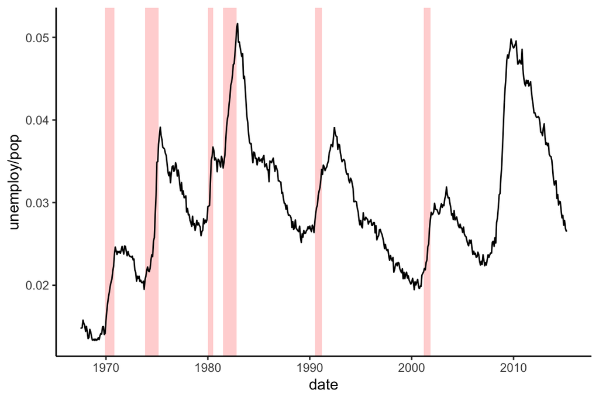

```r
recess = data.frame(
  begin = c("1969-12-01","1973-11-01","1980-01-01","1981-07-01","1990-07-01","2001-03-01"),
  end = c("1970-11-01","1975-03-01","1980-07-01","1982-11-01","1991-03-01","2001-11-01")
)
recess$begin = as.Date(recess$begin)
recess$end = as.Date(recess$end)

# Expand the following command with geom_rect() to draw the recess periods
ggplot(economics, aes(x = date, y = unemploy/pop)) +
  geom_rect(data = recess,
            aes(xmin = begin, xmax = end, ymin = -Inf, ymax = +Inf),
            inherit.aes = FALSE, fill = "red", alpha = 0.2) +
  geom_line()
```

# 5. qplot and wrap-up

## 5.1 `qplot()`

1. `qplot()` is a basic alternative to `ggplot2` scatter plot: easy, quick, and dirty.

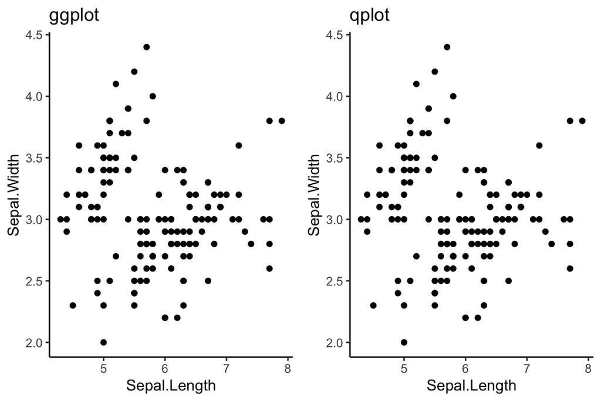

```r
q1 =  ggplot(iris, aes(x = Sepal.Length, y = Sepal.Width)) +
  geom_point() + labs(title = "ggplot")
q2 =  qplot(Sepal.Length, Sepal.Width, data = iris) + labs(title = "qplot")

grid.arrange(q1,q2, ncol=2)
```

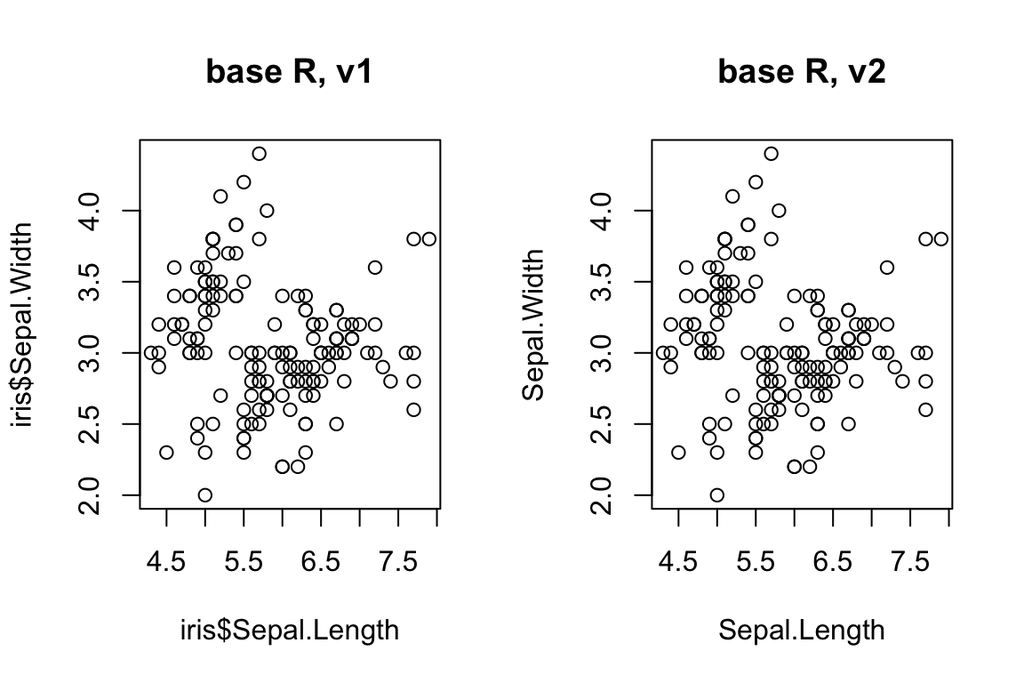

```r
par(mfrow=c(1,2))

plot(iris$Sepal.Length, iris$Sepal.Width, main = "base R, v1")
plot(Sepal.Width ~ Sepal.Length, data = iris, main = "base R, v2")
```

The following part is to try a ggplot + base R layout.

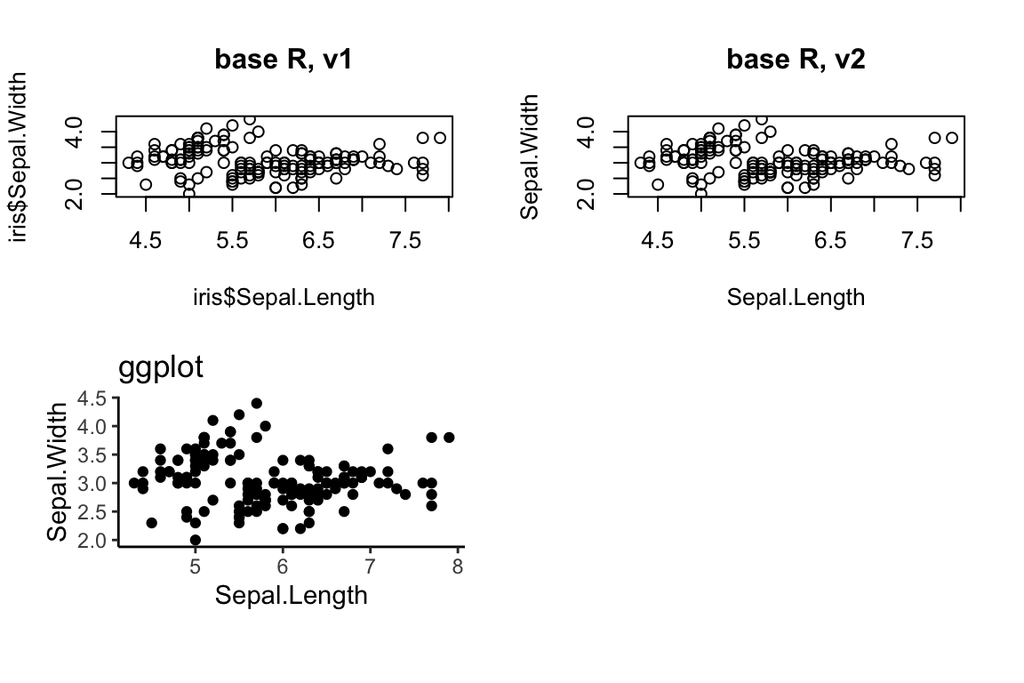

```r
library(gridBase)
library(grid)
par(mfrow=c(2, 2))

plot(iris$Sepal.Length, iris$Sepal.Width, main = "base R, v1")
plot(Sepal.Width ~ Sepal.Length, data = iris, main = "base R, v2")

plot.new()              ## suggested by @Josh
vps <- baseViewports()
pushViewport(vps$figure) ##   I am in the space of the autocorrelation plot
vp1 <-plotViewport(c(1.8,1,0,1)) ## create new vp with margins, you play with this values
require(ggplot2)

q1 = ggplot(iris, aes(x = Sepal.Length, y = Sepal.Width)) +
  geom_point() + labs(title = "ggplot")
q2 = qplot(Sepal.Length, Sepal.Width, data = iris) + labs(title = "qplot")
print(q1,vp = vp1)
```

2. Choosing geoms

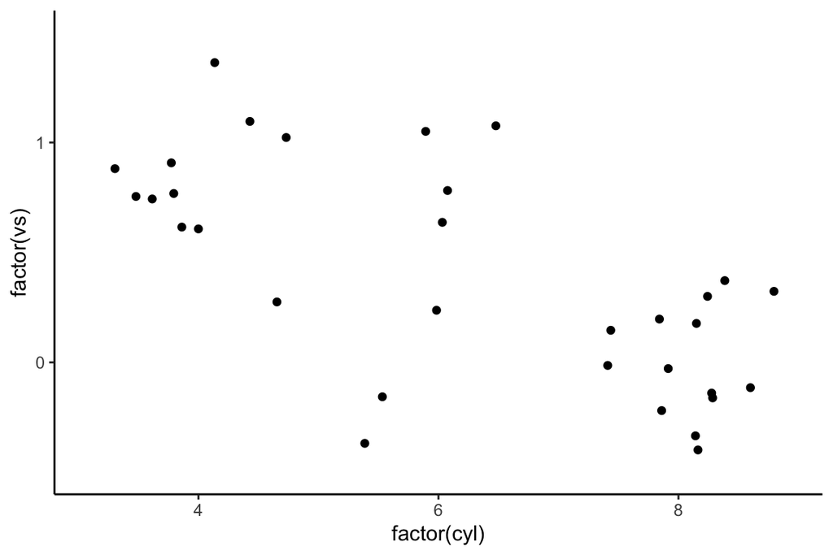

```r
qplot(x=factor(cyl), y=factor(vs), data = mtcars, geom = "jitter")
```

3. `geom_dotplot()`

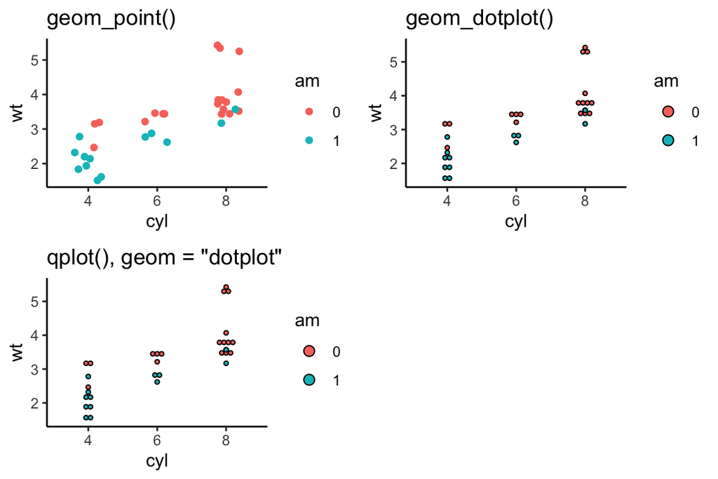

```r
# "Basic" dot plot, with geom_point():
dot1 = ggplot(mtcars, aes(cyl, wt, col = am)) +
  geom_point(position = position_jitter(0.2, 0)) + labs(title = "geom_point()")

# 1 - "True" dot plot, with geom_dotplot():
dot2 = ggplot(mtcars, aes(cyl, wt, fill = am)) +
  geom_dotplot(binaxis = "y", stackdir = "center") + labs(title = "geom_dotplot()")

# 2 - qplot with geom "dotplot", binaxis = "y" and stackdir = "center"
dot3 = qplot(
  cyl, wt,
  data = mtcars,
  fill = am,
  geom = "dotplot",
  binaxis = "y",
  stackdir = "center"
) + labs(title = "qplot(), geom = \"dotplot\"")

grid.arrange(dot1,dot2,dot3, ncol=2)
```

## 5.2 Wrap-up

### Ex 1. Chicken weight with summary statistics

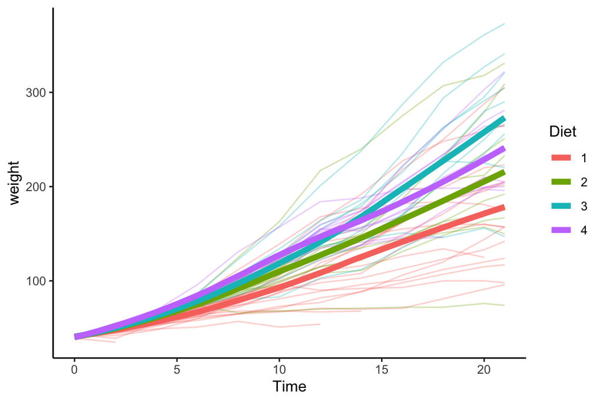

```r
ggplot(ChickWeight, aes(x = Time, y = weight, color = Diet)) +
  geom_line(aes(group = Chick), alpha=0.3) +
  geom_smooth(lwd=2, se=FALSE)
```